# Karen’s Basket — Perturbation Analysis

Data-quality audit and Karen-adjacent alternative baskets

Grocery Pricing Project

April 29, 2026

# 1 Mission

The 60-item Karen’s Basket (defined in `target_items.py`) is the project’s reference basket for U.S. grocery inflation in 2020-2025. This report *perturbs* that basket: starting from the same 60 conceptual targets, it runs a data-quality audit, identifies items whose underlying parquet support is weak, mines parquet-verified substitutes for the same grocery roles, and proposes three alternative baskets (`Karen-Lean`, `Karen-Robust`, `Karen-Broad`) for sensitivity analysis.

The goal is **plausible, robust, Karen-adjacent meals**: every alternative preserves Karen’s spirit (everyday American groceries) while improving the chain breadth, year coverage, and unit homogeneity of the underlying panel.

# 2 Data-quality audit of the 60 Karen items

For every Karen label we matched the `target_items.py` regex against unique product names in the full parquet (2020-2025, non-sale only). For each label we then computed:

- `n_rows` — total matched rows
- `n_chains` — distinct chains contributing
- `n_years` — distinct years (out of 6) with at least one observation
- `dominant_unit` and `unit_homogeneity` — share of rows whose `unit` field matches the most common value
- `iqr_over_median` — robust price dispersion
- `outlier_share` — average within-year share of Tukey-fence outliers on log price
- a `verdict` and a one-line `verdict_reason`.

Verdict distribution across the 60 Karen labels

| Verdict | n labels | Share | Share % |
| --- | --- | --- | --- |
| keep | 23 | 0.3833333 | 38.3% |
| keep-tighten | 37 | 0.6166667 | 61.7% |
| replace | 0 | 0.0000000 | 0.0% |
| drop | 0 | 0.0000000 | 0.0% |

In the current snapshot every Karen label matches enough data to clear the ‘drop’ threshold (`n_rows >= 25` and `n_years >= 3`), so the audit splits into **keep** and **keep-tighten**. The keep-tighten flag mostly catches unit-field heterogeneity (many chains expose blank or inconsistent units) and a handful of high-IQR-over-median labels driven by package-size mixing.

## 2.1 Coverage by year

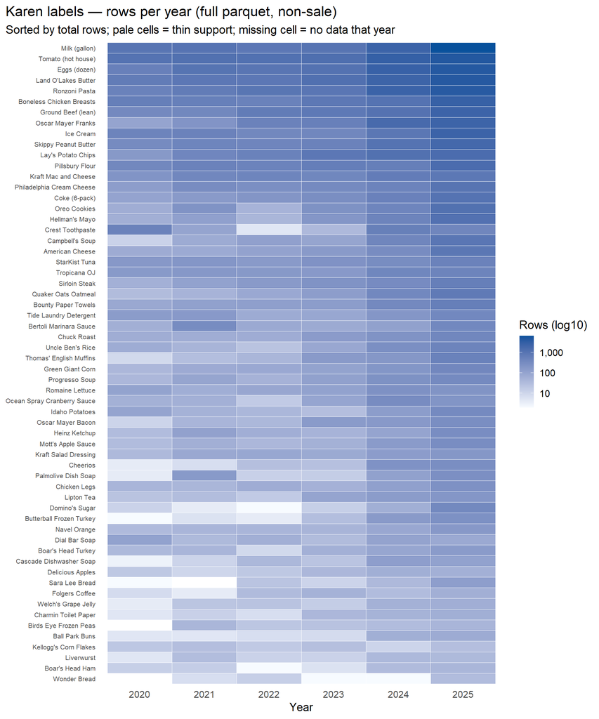

## 2.2 Per-label QC table

The full table sorted by verdict and then descending row count. Items most in need of tightening are those with `unit_homogeneity` below 0.5 or `iqr_over_median` above 1.5 — they appear at the top of the keep-tighten group.

Per-Karen-label QC stats with verdict and one-line reason

| Label | Verdict | Years | Chains | Rows | Dominant unit | Unit homog. | IQR / median | Outlier % | Reason |
| --- | --- | --- | --- | --- | --- | --- | --- | --- | --- |
| Milk (gallon) | keep | 6 | 108 | 12,651 | (blank) | 51% | 0.85 | 10.3% | 12651 rows over 6 years across 108 chains |
| Eggs (dozen) | keep | 6 | 109 | 10,482 | (blank) | 51% | 1.27 | 1.9% | 10482 rows over 6 years across 109 chains |
| Ice Cream | keep | 6 | 46 | 4,985 | (blank) | 55% | 0.46 | 13.5% | 4985 rows over 6 years across 46 chains |
| Skippy Peanut Butter | keep | 6 | 52 | 4,668 | (blank) | 53% | 1.10 | 2.8% | 4668 rows over 6 years across 52 chains |
| Lay’s Potato Chips | keep | 6 | 48 | 4,660 | bag | 51% | 0.30 | 18.6% | 4660 rows over 6 years across 48 chains |
| Philadelphia Cream Cheese | keep | 6 | 49 | 2,540 | (blank) | 55% | 0.93 | 5.2% | 2540 rows over 6 years across 49 chains |
| StarKist Tuna | keep | 6 | 15 | 1,545 | (blank) | 70% | 1.12 | 1.4% | 1545 rows over 6 years across 15 chains |
| Bertoli Marinara Sauce | keep | 6 | 20 | 1,012 | (blank) | 61% | 0.67 | 8.9% | 1012 rows over 6 years across 20 chains |
| Green Giant Corn | keep | 6 | 15 | 878 | (blank) | 58% | 0.62 | 7.3% | 878 rows over 6 years across 15 chains |
| Romaine Lettuce | keep | 6 | 32 | 817 | (blank) | 56% | 0.61 | 10.3% | 817 rows over 6 years across 32 chains |
| Ocean Spray Cranberry Sauce | keep | 6 | 20 | 725 | (blank) | 68% | 0.58 | 12.8% | 725 rows over 6 years across 20 chains |
| Heinz Ketchup | keep | 6 | 22 | 646 | (blank) | 70% | 1.14 | 2.2% | 646 rows over 6 years across 22 chains |
| Kraft Salad Dressing | keep | 6 | 25 | 606 | (blank) | 69% | 0.50 | 6.1% | 606 rows over 6 years across 25 chains |
| Palmolive Dish Soap | keep | 6 | 15 | 569 | (blank) | 54% | 0.84 | 9.7% | 569 rows over 6 years across 15 chains |
| Dial Bar Soap | keep | 6 | 15 | 418 | lb | 50% | 0.77 | 0.3% | 418 rows over 6 years across 15 chains |
| Boar’s Head Turkey | keep | 6 | 7 | 392 | lb | 60% | 0.63 | 3.8% | 392 rows over 6 years across 7 chains |
| Sara Lee Bread | keep | 5 | 9 | 201 | 1 lb | 56% | 0.38 | 11.4% | 201 rows over 5 years across 9 chains |
| Folgers Coffee | keep | 6 | 14 | 189 | (blank) | 55% | 0.57 | 5.0% | 189 rows over 6 years across 14 chains |
| Welch’s Grape Jelly | keep | 6 | 9 | 180 | (blank) | 69% | 1.33 | 8.3% | 180 rows over 6 years across 9 chains |
| Charmin Toilet Paper | keep | 6 | 18 | 175 | (blank) | 52% | 1.12 | 3.8% | 175 rows over 6 years across 18 chains |
| Birds Eye Frozen Peas | keep | 5 | 6 | 166 | (blank) | 76% | 0.38 | 7.2% | 166 rows over 5 years across 6 chains |
| Kellogg’s Corn Flakes | keep | 6 | 7 | 135 | (blank) | 70% | 1.34 | 10.0% | 135 rows over 6 years across 7 chains |
| Wonder Bread | keep | 5 | 8 | 57 | (blank) | 53% | 0.13 | 14.1% | 57 rows over 5 years across 8 chains |
| Tomato (hot house) | keep-tighten | 6 | 110 | 12,089 | (blank) | 53% | 1.63 | 4.9% | high price dispersion (IQR/median = 1.63) |
| Land O’Lakes Butter | keep-tighten | 6 | 108 | 10,072 | (blank) | 53% | 1.64 | 3.4% | high price dispersion (IQR/median = 1.64) |
| Ronzoni Pasta | keep-tighten | 6 | 75 | 9,466 | (blank) | 39% | 1.67 | 2.5% | unit heterogeneity (dominant unit ’’ = 39%) |
| Boneless Chicken Breasts | keep-tighten | 6 | 82 | 6,238 | (blank) | 30% | 1.36 | 7.5% | unit heterogeneity (dominant unit ’’ = 30%) |
| Ground Beef (lean) | keep-tighten | 6 | 83 | 5,673 | lb | 42% | 1.19 | 3.9% | unit heterogeneity (dominant unit ‘lb’ = 42%) |
| Oscar Mayer Franks | keep-tighten | 6 | 39 | 5,289 | package | 31% | 0.81 | 8.6% | unit heterogeneity (dominant unit ‘package’ = 31%) |
| Pillsbury Flour | keep-tighten | 6 | 62 | 4,055 | (blank) | 52% | 1.75 | 3.0% | high price dispersion (IQR/median = 1.75) |
| Kraft Mac and Cheese | keep-tighten | 6 | 56 | 2,952 | (blank) | 39% | 0.96 | 5.9% | unit heterogeneity (dominant unit ’’ = 39%) |
| Coke (6-pack) | keep-tighten | 6 | 29 | 2,340 | (blank) | 36% | 1.61 | 2.0% | unit heterogeneity (dominant unit ’’ = 36%) |
| Oreo Cookies | keep-tighten | 6 | 30 | 2,188 | (blank) | 56% | 5.06 | 11.0% | high price dispersion (IQR/median = 5.06) |
| Hellman’s Mayo | keep-tighten | 6 | 43 | 2,021 | (blank) | 33% | 1.63 | 5.4% | unit heterogeneity (dominant unit ’’ = 33%) |
| Crest Toothpaste | keep-tighten | 6 | 19 | 1,624 | (blank) | 39% | 0.65 | 6.2% | unit heterogeneity (dominant unit ’’ = 39%) |
| Campbell’s Soup | keep-tighten | 6 | 16 | 1,601 | (blank) | 24% | 0.47 | 15.0% | unit heterogeneity (dominant unit ’’ = 24%) |
| American Cheese | keep-tighten | 6 | 35 | 1,579 | (blank) | 25% | 1.06 | 8.1% | unit heterogeneity (dominant unit ’’ = 25%) |
| Tropicana OJ | keep-tighten | 6 | 47 | 1,534 | (blank) | 46% | 0.73 | 5.4% | unit heterogeneity (dominant unit ’’ = 46%) |
| Sirloin Steak | keep-tighten | 6 | 53 | 1,453 | lb | 48% | 1.28 | 0.0% | unit heterogeneity (dominant unit ‘lb’ = 48%) |
| Quaker Oats Oatmeal | keep-tighten | 6 | 39 | 1,404 | (blank) | 32% | 0.78 | 8.0% | unit heterogeneity (dominant unit ’’ = 32%) |
| Bounty Paper Towels | keep-tighten | 6 | 30 | 1,398 | ea | 42% | 0.93 | 3.7% | unit heterogeneity (dominant unit ‘ea’ = 42%) |
| Tide Laundry Detergent | keep-tighten | 6 | 33 | 1,035 | (blank) | 49% | 0.86 | 10.0% | unit heterogeneity (dominant unit ’’ = 49%) |
| Chuck Roast | keep-tighten | 6 | 38 | 962 | lb | 42% | 0.84 | 2.2% | unit heterogeneity (dominant unit ‘lb’ = 42%) |
| Uncle Ben’s Rice | keep-tighten | 6 | 7 | 955 | (blank) | 38% | 0.97 | 9.2% | unit heterogeneity (dominant unit ’’ = 38%) |
| Thomas’ English Muffins | keep-tighten | 6 | 24 | 931 | (blank) | 18% | 0.78 | 7.6% | unit heterogeneity (dominant unit ’’ = 18%) |
| Progresso Soup | keep-tighten | 6 | 9 | 872 | (blank) | 41% | 0.57 | 6.3% | unit heterogeneity (dominant unit ’’ = 41%) |
| Idaho Potatoes | keep-tighten | 6 | 35 | 697 | (blank) | 32% | 0.72 | 6.9% | unit heterogeneity (dominant unit ’’ = 32%) |
| Oscar Mayer Bacon | keep-tighten | 6 | 18 | 693 | 16 oz | 23% | 0.62 | 5.7% | unit heterogeneity (dominant unit ‘16 oz’ = 23%) |
| Mott’s Apple Sauce | keep-tighten | 6 | 23 | 628 | lb | 33% | 1.31 | 10.6% | unit heterogeneity (dominant unit ‘lb’ = 33%) |
| Cheerios | keep-tighten | 6 | 13 | 577 | (blank) | 24% | 0.90 | 10.7% | unit heterogeneity (dominant unit ’’ = 24%) |
| Chicken Legs | keep-tighten | 6 | 39 | 564 | (blank) | 39% | 6.12 | 3.3% | unit heterogeneity (dominant unit ’’ = 39%) |
| Lipton Tea | keep-tighten | 6 | 16 | 503 | (blank) | 41% | 1.05 | 2.2% | unit heterogeneity (dominant unit ’’ = 41%) |
| Domino’s Sugar | keep-tighten | 6 | 9 | 452 | case | 17% | 1.10 | 4.4% | unit heterogeneity (dominant unit ‘case’ = 17%) |
| Butterball Frozen Turkey | keep-tighten | 6 | 11 | 444 | package | 23% | 1.08 | 5.1% | unit heterogeneity (dominant unit ‘package’ = 23%) |
| Navel Orange | keep-tighten | 6 | 25 | 426 | (blank) | 29% | 1.42 | 0.7% | unit heterogeneity (dominant unit ’’ = 29%) |
| Cascade Dishwasher Soap | keep-tighten | 6 | 12 | 313 | (blank) | 28% | 0.63 | 0.6% | unit heterogeneity (dominant unit ’’ = 28%) |
| Delicious Apples | keep-tighten | 6 | 15 | 204 | (blank) | 42% | 1.53 | 6.2% | unit heterogeneity (dominant unit ’’ = 42%) |
| Ball Park Buns | keep-tighten | 6 | 10 | 157 | 14 oz | 17% | 0.29 | 18.6% | unit heterogeneity (dominant unit ‘14 oz’ = 17%) |
| Liverwurst | keep-tighten | 6 | 8 | 134 | lb | 44% | 0.71 | 8.9% | unit heterogeneity (dominant unit ‘lb’ = 44%) |
| Boar’s Head Ham | keep-tighten | 6 | 6 | 113 | (blank) | 30% | 3.22 | 0.0% | unit heterogeneity (dominant unit ’’ = 30%) |

## 2.3 Worst offenders — examples

For the labels with the lowest unit homogeneity or the highest dispersion, the most common matched product names give a feel for *why* the panel is noisy:

Eight ‘keep-tighten’ labels and their top 5 matched product names. The mix of package sizes / variants is what drives the unit and price-dispersion flags.

| Label | Product name | Rows |
| --- | --- | --- |
| American Cheese | American Cheese Slices | 483 |
| American Cheese | White American Cheese | 81 |
| American Cheese | Sliced American Cheese | 78 |
| American Cheese | American Cheese Singles | 32 |
| American Cheese | American Cheese | 31 |
| Ball Park Buns | Ball Park Hot Dog Buns, 8 count, 14 oz | 21 |
| Ball Park Buns | Ball Park Everything Hamburger Buns, 8 count, 16 oz | 14 |
| Ball Park Buns | Ball Park Burger Buns, 8 count, 15 oz | 11 |
| Ball Park Buns | Ball Park Bun Size Beef Franks | 10 |
| Ball Park Buns | Ball Park Bun Size Meat Franks | 10 |
| Butterball Frozen Turkey | Butterball Turkey Sausage | 101 |
| Butterball Frozen Turkey | Butterball Boneless Turkey Breast Roast Meat, 48 oz | 33 |
| Butterball Frozen Turkey | Butterball All Natural Ground Turkey, 48 oz | 25 |
| Butterball Frozen Turkey | Butterball Oven Roasted Turkey Breast | 20 |
| Butterball Frozen Turkey | Butterball Turkey Ham | 17 |
| Campbell’s Soup | Campbell’s Chicken Noodle Soup | 29 |
| Campbell’s Soup | Campbell’s Condensed Bean with Bacon Soup, 11.25 oz | 24 |
| Campbell’s Soup | Campbell’s Condensed Cream of Chicken Soup, 10.5 oz | 23 |
| Campbell’s Soup | Campbell’s Chunky Chicken Broccoli Cheese with Potato Soup, 18.8 oz | 23 |
| Campbell’s Soup | Campbell’s Chunky Smoked Turkey with White & Wild Rice Soup, 18.6 oz | 22 |
| Cheerios | Honey Nut Cheerios | 81 |
| Cheerios | General Mills Cheerios Honey Nut Cereal, 10.8 oz | 39 |
| Cheerios | General Mills Cheerios Honey Nut Cereal Large Size, 15.4 oz | 38 |
| Cheerios | Cheerios | 33 |
| Cheerios | General Mills Cheerios Toasted Whole Grain Oat Cereal Large Size, 12 oz | 31 |
| Domino’s Sugar | Domino Granulated Sugar | 71 |
| Domino’s Sugar | Domino Premium Pure Cane Granulated Sugar, 4 lb | 46 |
| Domino’s Sugar | Domino Organic Raw Cane Sugar, 24 oz | 29 |
| Domino’s Sugar | Domino Premium Pure Cane Granulated Sugar, 10 lb | 19 |
| Domino’s Sugar | Domino Premium Pure Cane Sugar Cubes, 126 count, 16 oz | 18 |
| Oscar Mayer Bacon | Oscar Mayer Fully Cooked Bacon | 27 |
| Oscar Mayer Bacon | Oscar Mayer Beef Franks | 23 |
| Oscar Mayer Bacon | Oscar Mayer Deli Fresh Honey Smoked Turkey Breast, 9 oz | 14 |
| Oscar Mayer Bacon | Oscar Mayer Deli Fresh Oven Roasted Turkey Breast, 8 oz | 13 |
| Oscar Mayer Bacon | Oscar Mayer Meat Wieners | 12 |
| Thomas’ English Muffins | Turkey Sasuage, Egg Whites & Cheese English Muffins | 116 |
| Thomas’ English Muffins | English Muffin & French Croissant Medley | 56 |
| Thomas’ English Muffins | Food For Life Ezekiel 4:9 Sprouted Grain English Muffins, 6 count, 16 oz | 33 |
| Thomas’ English Muffins | Food For Life Ezekiel 4:9 Cinnamon Raisin Sprouted Grain English Muffins, 6 count, 16 oz | 31 |
| Thomas’ English Muffins | Original English Muffins | 29 |